# Malaysian Economic and Agriculture Price 2019 Prediction

Valentina Zhong (63260335)

31/03/2022

# Background: Malaysia in 2018

This analysis draws inspiration and data from previous work performed by Mohaddes & Raissi (2020) in which economic data along with industry indicators are studied to forecast futures values. The intent of this analysis is to understand and explain the economic situation within the country of Malaysia while giving attention to the agriculture sector to forecast 2019 values. The chosen country of interest, Malaysia, was selected because of its unique position as an economy transitioning from upper-middle income to high income. The Southeast Asian country boasted a population of 32.4 million in 2018 with a GDP per capita of $11,380.82 (Current $USD) (Mahidin, 2019b, World Bank, 2022). This level of income makes it one of the wealthiest countries in Southeast Asia. This analysis will investigate and forecast the agriculture sector in addition to the economic indicators provided within the dataset.

# Dataset

- [University of Cambridge Global VAR (GVAR) Database, 1979Q2-2019Q4](https://www.repository.cam.ac.uk/handle/1810/309672)

# Roadmap

Based on a time series dataset, we will apply different time series models to predict the economic performance and agriculture price in 2019. The analysis mainly develop into three parts. Stationary is one of the most important assumptions for time series modelling. Therefore, we start from the stationary test before model specification. During the model construction, the data will be divided into two groups, which are training set and testing set. To evaluate the accuracy of models, accuracy matrix will be designed, where there are different type of error terms. After the accuracy analysis, several model characteristic will be examined, which include series correlation and heteroskedasticity.

# Methodology

```r
pacman::p_load(here, readr, dplyr,tidyr, janitor, xts, lubridate, urca, forecast, vars, modelsummary, readxl, readxl, Quandl, tseries, lmtest, data.table, writexl, ggplot2, ggpubr,zoo,gridExtra)
```

### Stationary Analysis on the Whole Dataset

```r
data <- read_excel(here("data","Data.xlsx"))

data$date <- as.Date(as.yearqtr(data$date, format = "%YQ%q"))
# y <- natural logarithm of real GDP
# Dp <- the rate of inflation, calculated by taking the difference of the natural logarithm of the consumer price index
# eq <- natural logarithm of the nominal equity price index deflated by CPI
# ep <- natural logarithm of the exchange rate of country i at time t expressed in US dollars deflated by country i's eq
# r <- nominal short-term interest rate per quarter, in per cent
# lr <- nominal long-term interest rate per quarter, in per cent (computed as 0.25ln(1+ /100)) <- we do not have
# pmat <- natural logarithm of the nominal price of agricultural raw material in US dollars

data <- data %>%
  mutate(lngdp = as.numeric(y),
         inflat = as.numeric(Dp),
         lneq = as.numeric(eq),
         lnex = as.numeric(ep),
         r = as.numeric(r),
         agri = as.numeric(pmat))%>%
  dplyr::select(date,lngdp,inflat,lneq,lnex,r,agri)
head(data)
```

```
## # A tibble: 6 × 7
##   date       lngdp inflat  lneq  lnex       r  agri
##   <date>     <dbl>  <dbl> <dbl> <dbl>   <dbl> <dbl>
## 1 1979-04-01  3.26 0.0138 0.782 -3.06 0.00757  4.15
## 2 1979-07-01  3.28 0.0143 0.889 -3.11 0.00769  4.27
## 3 1979-10-01  3.30 0.0184 0.887 -3.11 0.00842  4.22
## 4 1980-01-01  3.32 0.0151 0.931 -3.12 0.00879  4.31
## 5 1980-04-01  3.34 0.0111 1.17  -3.13 0.00983  4.21
## 6 1980-07-01  3.35 0.0221 1.23  -3.18 0.0102   4.29
```

```r
datasummary_skim(data[,-1],histogram=FALSE,title="Data Summary")
```

Data Summary

|  | Unique (#) | Missing (%) | Mean | SD | Min | Median | Max |
| --- | --- | --- | --- | --- | --- | --- | --- |
| lngdp | 163 | 0 | 4.5 | 0.7 | 3.3 | 4.6 | 5.5 |
| inflat | 163 | 0 | 0.0 | 0.0 | −0.0 | 0.0 | 0.0 |
| lneq | 163 | 0 | 1.6 | 0.4 | 0.3 | 1.6 | 2.2 |
| lnex | 163 | 0 | −3.4 | 0.2 | −3.8 | −3.4 | −3.1 |
| r | 153 | 0 | 0.0 | 0.0 | 0.0 | 0.0 | 0.0 |
| agri | 163 | 0 | 4.6 | 0.2 | 4.1 | 4.6 | 5.1 |

### Data Regroup

```r
# set cutoff date for training and validation (test) periods
cutoff_date = "2018-10-01"

# 2. Creating training and forecasting datasets
## 2.1 Training dataset
data_set_train <- data %>%
  filter(data$date <= cutoff_date)

## 2. Forecasting dataset
data_set_fore <- data %>% filter(data$date > cutoff_date)

fore_period <- nrow(data_set_fore)
```

### Training Dataset by Models

```r
## 1. ARIMA
arima_train_agri <-
  auto.arima(data_set_train$agri, max.p = 8, max.q = 8, max.d = 2,
             method = "ML", approximation = FALSE,
             ic = "aic", stepwise = FALSE)
arima_train_lngdp <-
  auto.arima(data_set_train$lngdp, max.p = 8, max.q = 8, max.d = 2,
             method = "ML", approximation = FALSE,
             ic = "aic", stepwise = FALSE)
arima_train_lneq <-
  auto.arima(data_set_train$lneq, max.p = 8, max.q = 8, max.d = 2,
             method = "ML", approximation = FALSE,
             ic = "aic", stepwise = FALSE)
arima_train_lnex <-
  auto.arima(data_set_train$lnex, max.p = 8, max.q = 8, max.d = 2,
             method = "ML", approximation = FALSE,
             ic = "aic", stepwise = FALSE)
arima_train_r <-
  auto.arima(data_set_train$r, max.p = 8, max.q = 8, max.d = 2,
             method = "ML", approximation = FALSE,
             ic = "aic", stepwise = FALSE)
arima_train_inflat <-
  auto.arima(data_set_train$inflat, max.p = 8, max.q = 8, max.d = 2,
             method = "ML", approximation = FALSE,
             ic = "aic", stepwise = FALSE)

## 2. Naive
naive_train_agri <- rwf(data_set_train$agri)
naive_train_lngdp <- rwf(data_set_train$lngdp)
naive_train_lneq <- rwf(data_set_train$lneq)
naive_train_lnex <- rwf(data_set_train$lnex)
naive_train_r<- rwf(data_set_train$r)
naive_train_inflat<- rwf(data_set_train$inflat)

arima_train_agri
```

```
## Series: data_set_train$agri
## ARIMA(0,1,3)
##
## Coefficients:
##          ma1     ma2      ma3
##       0.2496  0.0708  -0.2257
## s.e.  0.0786  0.0835   0.0822
##
## sigma^2 = 0.002924:  log likelihood = 238.16
## AIC=-468.32   AICc=-468.05   BIC=-456.06
```

```r
arima_train_lngdp
```

```
## Series: data_set_train$lngdp
## ARIMA(3,1,2) with drift
##
## Coefficients:
##          ar1      ar2     ar3     ma1     ma2   drift
##       0.2742  -0.7248  0.3208  0.0180  0.9532  0.0139
## s.e.  0.0839   0.0791  0.0796  0.0404  0.0484  0.0018
##
## sigma^2 = 0.0001758:  log likelihood = 461.05
## AIC=-908.1   AICc=-907.35   BIC=-886.66
```

```r
arima_train_lneq
```

```
## Series: data_set_train$lneq
## ARIMA(0,1,0)
##
## sigma^2 = 0.01649:  log likelihood = 100.09
## AIC=-198.19   AICc=-198.16   BIC=-195.12
```

```r
arima_train_lnex
```

```
## Series: data_set_train$lnex
## ARIMA(0,1,1)
##
## Coefficients:
##          ma1
##       0.3769
## s.e.  0.0702
##
## sigma^2 = 0.000984:  log likelihood = 323.22
## AIC=-642.44   AICc=-642.36   BIC=-636.32
```

```r
arima_train_r
```

```
## Series: data_set_train$r
## ARIMA(0,1,4)
##
## Coefficients:
##          ma1     ma2     ma3      ma4
##       0.0907  0.1417  0.0742  -0.2464
## s.e.  0.0765  0.0776  0.0748   0.0789
##
## sigma^2 = 1.347e-06:  log likelihood = 845.57
## AIC=-1681.13   AICc=-1680.74   BIC=-1665.82
```

```r
arima_train_inflat
```

```
## Series: data_set_train$inflat
## ARIMA(1,1,1)
##
## Coefficients:
##          ar1      ma1
##       0.1988  -0.8746
## s.e.  0.0999   0.0551
##
## sigma^2 = 4.368e-05:  log likelihood = 569.32
## AIC=-1132.64   AICc=-1132.49   BIC=-1123.45
```

### Forecasting Dataset by Models

```r
## 1. ARIMA
arima_fore_agri <- forecast(arima_train_agri, h = fore_period)
arima_fore_lngdp <- forecast(arima_train_lngdp, h = fore_period)
arima_fore_lneq <- forecast(arima_train_lneq, h = fore_period)
arima_fore_lnex <- forecast(arima_train_lnex, h = fore_period)
arima_fore_r <- forecast(arima_train_r, h = fore_period)
arima_fore_inflat <- forecast(arima_train_inflat, h = fore_period)
## 2. Naive - random walk
naive_fore_agri <- rwf(data_set_train$agri, h = fore_period)
naive_fore_lngdp <- rwf(data_set_train$lngdp, h = fore_period)
naive_fore_lneq <- rwf(data_set_train$lneq, h = fore_period)
naive_fore_lnex <- rwf(data_set_train$lnex, h = fore_period)
naive_fore_r <- rwf(data_set_train$r, h = fore_period)
naive_fore_inflat <- rwf(data_set_train$inflat, h = fore_period)
```

### Accuracy Matrix

**ARIMA Model**

```r
# Accuracy
accuracy(arima_train_agri$fitted, data_set_train$agri) #train
```

```
##                   ME       RMSE        MAE        MPE      MAPE
## Test set 0.003193748 0.05338582 0.04145654 0.06602377 0.9132258
```

```r
accuracy(arima_fore_agri$fitted,  data_set_fore$agri) # test
```

```
##                ME      RMSE      MAE      MPE     MAPE
## Test set 0.480018 0.4877714 0.480018 10.24369 10.24369
```

```r
accuracy(arima_train_lngdp$fitted, data_set_train$lngdp) #train
```

```
##                     ME       RMSE         MAE        MPE      MAPE
## Test set -2.267004e-06 0.01296535 0.008680769 0.00284815 0.2015996
```

```r
accuracy(arima_fore_lngdp$fitted,  data_set_fore$lngdp) # test
```

```
##                ME     RMSE      MAE      MPE     MAPE
## Test set 2.192115 2.192156 2.192115 40.00902 40.00902
```

```r
accuracy(arima_train_lneq$fitted, data_set_train$lneq) #train
```

```
##                   ME      RMSE        MAE        MPE     MAPE
## Test set 0.007102052 0.1280164 0.08819384 -0.2249453 7.494749
```

```r
accuracy(arima_fore_lneq$fitted,  data_set_fore$lneq) # test
```

```
##                ME     RMSE      MAE      MPE     MAPE
## Test set 1.030765 1.033832 1.030765 55.19694 55.19694
```

```r
accuracy(arima_train_lnex$fitted, data_set_train$lnex) #train
```

```
##                    ME       RMSE        MAE        MPE      MAPE
## Test set -0.002358962 0.03117149 0.02036359 0.06863338 0.5932143
```

```r
accuracy(arima_fore_lnex$fitted,  data_set_fore$lnex) # test
```

```
##                  ME      RMSE       MAE      MPE     MAPE
## Test set -0.5039493 0.5047056 0.5039493 14.02577 14.02577
```

```r
accuracy(arima_train_r$fitted, data_set_train$r) #train
```

```
##                    ME        RMSE          MAE        MPE     MAPE
## Test set 5.043593e-07 0.001142082 0.0005963861 -0.5264557 6.036618
```

```r
accuracy(arima_fore_r$fitted,  data_set_fore$r) # test
```

```
##                     ME         RMSE          MAE       MPE     MAPE
## Test set -0.0004942861 0.0007669568 0.0005998982 -6.977613 8.335488
```

```r
accuracy(arima_train_inflat$fitted, data_set_train$inflat) #train
```

```
##                     ME        RMSE         MAE      MPE     MAPE
## Test set -0.0004547367 0.006546074 0.004338344 377.2846 475.6931
```

```r
accuracy(arima_fore_inflat$fitted,  data_set_fore$inflat) # test
```

```
##                  ME       RMSE       MAE      MPE     MAPE
## Test set -0.0121266 0.01263416 0.0121266 229003.8 229165.9
```

**NAIVE Model**

```r
# Accuracy
accuracy(naive_train_agri$fitted, data_set_train$agri) #train
```

```
##                   ME       RMSE        MAE        MPE      MAPE
## Test set 0.003436213 0.05663162 0.04302265 0.07003719 0.9466781
```

```r
accuracy(naive_fore_agri$fitted,  data_set_fore$agri) # test
```

```
##                 ME      RMSE       MAE      MPE     MAPE
## Test set 0.4584834 0.4651792 0.4584834 9.802523 9.802523
```

```r
accuracy(naive_train_lngdp$fitted, data_set_train$lngdp) #train
```

```
##                  ME       RMSE        MAE       MPE      MAPE
## Test set 0.01388638 0.02016938 0.01672782 0.3245218 0.3873109
```

```r
accuracy(naive_fore_lngdp$fitted,  data_set_fore$lngdp) # test
```

```
##                ME     RMSE      MAE      MPE     MAPE
## Test set 2.202733 2.202758 2.202733 40.16913 40.16913
```

```r
accuracy(naive_train_lneq$fitted, data_set_train$lneq) #train
```

```
##                   ME      RMSE        MAE        MPE     MAPE
## Test set 0.007142051 0.1284208 0.08874707 -0.2270019 7.541551
```

```r
accuracy(naive_fore_lneq$fitted,  data_set_fore$lneq) # test
```

```
##                 ME     RMSE       MAE      MPE     MAPE
## Test set 0.9990967 1.001312 0.9990967 53.92128 53.92128
```

```r
accuracy(naive_train_lnex$fitted, data_set_train$lnex) #train
```

```
##                    ME      RMSE        MAE        MPE      MAPE
## Test set -0.003265673 0.0336408 0.02158294 0.09365888 0.6294348
```

```r
accuracy(naive_fore_lnex$fitted,  data_set_fore$lnex) # test
```

```
##                  ME      RMSE       MAE      MPE     MAPE
## Test set -0.4972722 0.4977157 0.4972722 13.84769 13.84769
```

```r
accuracy(naive_train_r$fitted, data_set_train$r) #train
```

```
##                    ME        RMSE         MAE        MPE    MAPE
## Test set 1.186668e-06 0.001192764 0.000603464 -0.6257254 6.11491
```

```r
accuracy(naive_fore_r$fitted,  data_set_fore$r) # test
```

```
##                     ME         RMSE          MAE       MPE     MAPE
## Test set -0.0006880865 0.0008259275 0.0006880865 -9.628704 9.628704
```

```r
accuracy(naive_train_inflat$fitted, data_set_train$inflat) #train
```

```
##                     ME        RMSE         MAE      MPE     MAPE
## Test set -6.423711e-05 0.007992702 0.004843636 452.6415 556.3551
```

```r
accuracy(naive_fore_inflat$fitted,  data_set_fore$inflat) # test
```

```
##                   ME       RMSE        MAE      MPE     MAPE
## Test set -0.01180772 0.01271957 0.01180772 348046.8 348258.5
```

However, because the data are not stationary at same level of integrate, we need to do the differential on the data set and VECM Model is not applicable in the predictions.

### Differential for Two Data Groups

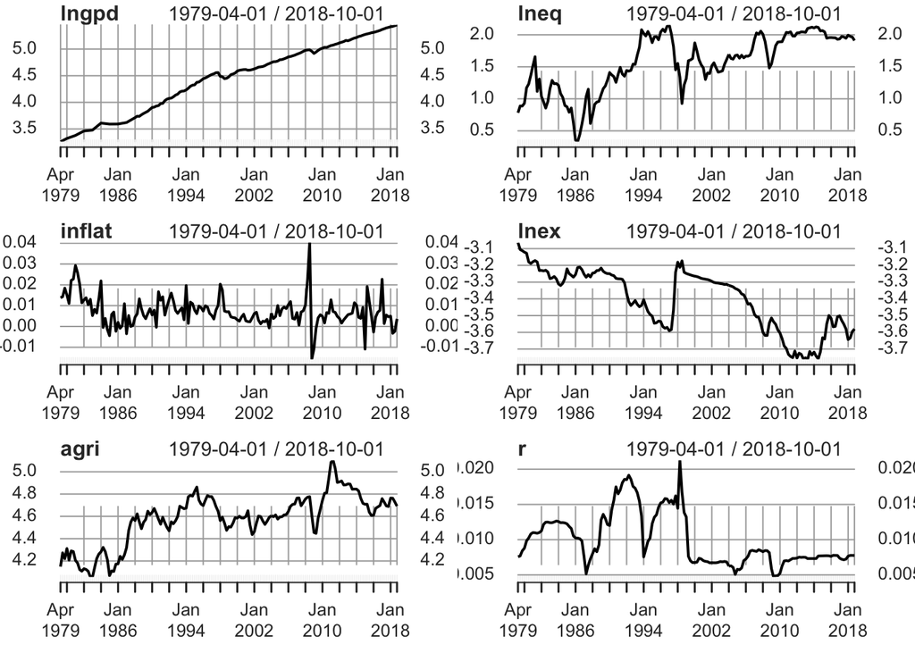

```r
data_set_train_ts <- xts(data_set_train[,-1], order.by = data_set_train$date)

par(mfrow=c(3,2))
plot(data_set_train_ts$lngdp,main= "lngpd")
plot(data_set_train_ts$lneq,main="lneq")
plot(data_set_train_ts$inflat,main="inflat")
plot(data_set_train_ts$lnex,main="lnex")
plot(data_set_train_ts$agri,main="agri")
plot(data_set_train_ts$r,main="r")
```

```r
data_set_fore_ts <- xts(data_set_fore[,-1], order.by = data_set_fore$date)

fore_period <- nrow(data_set_fore_ts)
```

### Stationary Test on the Differential Data from Training Group

```r
# Test for stationarity (levels) - ERS test
# Summary: All three data series are non-stationary at 5% or lower significance
summary(ur.ers(data_set_train_ts$lngdp, type = "DF-GLS", model = "trend", lag.max = 12)) # fail to reject -1.52 vs -2.93
```

```
##
## ###############################################
## # Elliot, Rothenberg and Stock Unit Root Test #
## ###############################################
##
## Test of type DF-GLS
## detrending of series with intercept and trend
##
##
## Call:
## lm(formula = dfgls.form, data = data.dfgls)
##
## Residuals:
##       Min        1Q    Median        3Q       Max
## -0.072544 -0.006041 -0.000695  0.007805  0.044555
##
## Coefficients:
##               Estimate Std. Error t value Pr(>|t|)
## yd.lag        -0.02294    0.01508  -1.521 0.130575
## yd.diff.lag1   0.31997    0.08570   3.734 0.000279 ***
## yd.diff.lag2   0.22884    0.08995   2.544 0.012100 *
## yd.diff.lag3  -0.05348    0.09134  -0.586 0.559193
## yd.diff.lag4  -0.11951    0.09125  -1.310 0.192581
## yd.diff.lag5  -0.12174    0.08911  -1.366 0.174163
## yd.diff.lag6   0.16576    0.08853   1.872 0.063357 .
## yd.diff.lag7   0.19564    0.08886   2.202 0.029424 *
## yd.diff.lag8  -0.23218    0.08957  -2.592 0.010606 *
## yd.diff.lag9  -0.03998    0.09086  -0.440 0.660676
## yd.diff.lag10  0.16601    0.09065   1.831 0.069286 .
## yd.diff.lag11  0.05140    0.09009   0.571 0.569218
## yd.diff.lag12 -0.01553    0.08660  -0.179 0.857970
## ---
## Signif. codes:  0 '***' 0.001 '**' 0.01 '*' 0.05 '.' 0.1 ' ' 1
##
## Residual standard error: 0.01377 on 133 degrees of freedom
## Multiple R-squared:  0.2459, Adjusted R-squared:  0.1722
## F-statistic: 3.336 on 13 and 133 DF,  p-value: 0.0001972
##
##
## Value of test-statistic is: -1.5212
##
## Critical values of DF-GLS are:
##                  1pct  5pct 10pct
## critical values -3.46 -2.93 -2.64
```

```r
summary(ur.ers(data_set_train_ts$inflat, type = "DF-GLS", model = "const", lag.max = 12)) # fail to reject -1.0386 vs -1.94
```

```
##
## ###############################################
## # Elliot, Rothenberg and Stock Unit Root Test #
## ###############################################
##
## Test of type DF-GLS
## detrending of series with intercept
##
##
## Call:
## lm(formula = dfgls.form, data = data.dfgls)
##
## Residuals:
##       Min        1Q    Median        3Q       Max
## -0.033380 -0.003874 -0.001168  0.001771  0.027492
##
## Coefficients:
##                Estimate Std. Error t value Pr(>|t|)
## yd.lag        -0.099826   0.096112  -1.039 0.300860
## yd.diff.lag1  -0.619068   0.123008  -5.033 1.54e-06 ***
## yd.diff.lag2  -0.543716   0.132957  -4.089 7.45e-05 ***
## yd.diff.lag3  -0.509581   0.138494  -3.679 0.000338 ***
## yd.diff.lag4  -0.496131   0.142668  -3.478 0.000684 ***
## yd.diff.lag5  -0.404861   0.144190  -2.808 0.005739 **
## yd.diff.lag6  -0.247116   0.145556  -1.698 0.091896 .
## yd.diff.lag7  -0.218024   0.144628  -1.507 0.134060
## yd.diff.lag8  -0.309428   0.138244  -2.238 0.026866 *
## yd.diff.lag9  -0.147267   0.130775  -1.126 0.262148
## yd.diff.lag10 -0.092869   0.120295  -0.772 0.441478
## yd.diff.lag11  0.005262   0.107392   0.049 0.960992
## yd.diff.lag12 -0.038151   0.088431  -0.431 0.666857
## ---
## Signif. codes:  0 '***' 0.001 '**' 0.01 '*' 0.05 '.' 0.1 ' ' 1
##
## Residual standard error: 0.006726 on 133 degrees of freedom
## Multiple R-squared:  0.3834, Adjusted R-squared:  0.3231
## F-statistic: 6.362 on 13 and 133 DF,  p-value: 3.049e-09
##
##
## Value of test-statistic is: -1.0386
##
## Critical values of DF-GLS are:
##                  1pct  5pct 10pct
## critical values -2.58 -1.94 -1.62
```

```r
summary(ur.ers(data_set_train_ts$lneq, type = "DF-GLS", model = "trend", lag.max = 12)) # fail to reject -2.3687 vs -2.93
```

```
##
## ###############################################
## # Elliot, Rothenberg and Stock Unit Root Test #
## ###############################################
##
## Test of type DF-GLS
## detrending of series with intercept and trend
##
##
## Call:
## lm(formula = dfgls.form, data = data.dfgls)
##
## Residuals:
##      Min       1Q   Median       3Q      Max
## -0.52476 -0.04132 -0.00070  0.06400  0.26777
##
## Coefficients:
##                Estimate Std. Error t value Pr(>|t|)
## yd.lag        -0.099626   0.042060  -2.369   0.0193 *
## yd.diff.lag1   0.223356   0.088441   2.525   0.0127 *
## yd.diff.lag2  -0.005668   0.088419  -0.064   0.9490
## yd.diff.lag3   0.079622   0.085961   0.926   0.3560
## yd.diff.lag4  -0.022177   0.079540  -0.279   0.7808
## yd.diff.lag5  -0.043462   0.079185  -0.549   0.5840
## yd.diff.lag6  -0.108778   0.078834  -1.380   0.1700
## yd.diff.lag7   0.036440   0.077630   0.469   0.6396
## yd.diff.lag8   0.096106   0.076068   1.263   0.2086
## yd.diff.lag9  -0.078396   0.075552  -1.038   0.3013
## yd.diff.lag10  0.034890   0.075801   0.460   0.6461
## yd.diff.lag11  0.123437   0.075786   1.629   0.1057
## yd.diff.lag12  0.019904   0.075934   0.262   0.7936
## ---
## Signif. codes:  0 '***' 0.001 '**' 0.01 '*' 0.05 '.' 0.1 ' ' 1
##
## Residual standard error: 0.1135 on 133 degrees of freedom
## Multiple R-squared:  0.1649, Adjusted R-squared:  0.08325
## F-statistic:  2.02 on 13 and 133 DF,  p-value: 0.02358
##
##
## Value of test-statistic is: -2.3687
##
## Critical values of DF-GLS are:
##                  1pct  5pct 10pct
## critical values -3.46 -2.93 -2.64
```

```r
summary(ur.ers(data_set_train_ts$lnex, type = "DF-GLS", model = "trend", lag.max = 12)) # fail to reject -2.3613 vs -2.93
```

```
##
## ###############################################
## # Elliot, Rothenberg and Stock Unit Root Test #
## ###############################################
##
## Test of type DF-GLS
## detrending of series with intercept and trend
##
##
## Call:
## lm(formula = dfgls.form, data = data.dfgls)
##
## Residuals:
##       Min        1Q    Median        3Q       Max
## -0.076518 -0.019298 -0.001297  0.010558  0.172857
##
## Coefficients:
##                 Estimate Std. Error t value Pr(>|t|)
## yd.lag        -0.0663288  0.0280901  -2.361   0.0197 *
## yd.diff.lag1   0.4279801  0.0852857   5.018 1.64e-06 ***
## yd.diff.lag2  -0.0759746  0.0929228  -0.818   0.4150
## yd.diff.lag3   0.0251518  0.0922930   0.273   0.7856
## yd.diff.lag4   0.0171896  0.0932661   0.184   0.8541
## yd.diff.lag5   0.0148723  0.0931113   0.160   0.8733
## yd.diff.lag6  -0.0075105  0.0930579  -0.081   0.9358
## yd.diff.lag7   0.1312462  0.0927374   1.415   0.1593
## yd.diff.lag8   0.0010095  0.0927969   0.011   0.9913
## yd.diff.lag9  -0.0106602  0.0933826  -0.114   0.9093
## yd.diff.lag10 -0.0001969  0.0932597  -0.002   0.9983
## yd.diff.lag11  0.0845933  0.0933219   0.906   0.3663
## yd.diff.lag12 -0.0251637  0.0882030  -0.285   0.7759
## ---
## Signif. codes:  0 '***' 0.001 '**' 0.01 '*' 0.05 '.' 0.1 ' ' 1
##
## Residual standard error: 0.03216 on 133 degrees of freedom
## Multiple R-squared:  0.1938, Adjusted R-squared:  0.115
## F-statistic:  2.46 on 13 and 133 DF,  p-value: 0.005017
##
##
## Value of test-statistic is: -2.3613
##
## Critical values of DF-GLS are:
##                  1pct  5pct 10pct
## critical values -3.46 -2.93 -2.64
```

```r
summary(ur.ers(data_set_train_ts$r, type = "DF-GLS", model = "const", lag.max = 12)) # fail to reject -1.8261 vs -1.94
```

```
##
## ###############################################
## # Elliot, Rothenberg and Stock Unit Root Test #
## ###############################################
##
## Test of type DF-GLS
## detrending of series with intercept
##
##
## Call:
## lm(formula = dfgls.form, data = data.dfgls)
##
## Residuals:
##        Min         1Q     Median         3Q        Max
## -0.0051585 -0.0001616  0.0000224  0.0003420  0.0072712
##
## Coefficients:
##               Estimate Std. Error t value Pr(>|t|)
## yd.lag        -0.05029    0.02754  -1.826  0.07009 .
## yd.diff.lag1   0.09089    0.08614   1.055  0.29324
## yd.diff.lag2   0.15979    0.08642   1.849  0.06668 .
## yd.diff.lag3   0.10346    0.08749   1.182  0.23914
## yd.diff.lag4  -0.23153    0.08795  -2.632  0.00948 **
## yd.diff.lag5   0.09370    0.08802   1.065  0.28901
## yd.diff.lag6   0.10741    0.08822   1.218  0.22557
## yd.diff.lag7  -0.01659    0.08852  -0.187  0.85166
## yd.diff.lag8  -0.18533    0.08845  -2.095  0.03805 *
## yd.diff.lag9   0.04708    0.08646   0.545  0.58696
## yd.diff.lag10  0.07415    0.08641   0.858  0.39242
## yd.diff.lag11  0.00861    0.08601   0.100  0.92041
## yd.diff.lag12 -0.06130    0.08591  -0.714  0.47676
## ---
## Signif. codes:  0 '***' 0.001 '**' 0.01 '*' 0.05 '.' 0.1 ' ' 1
##
## Residual standard error: 0.001205 on 133 degrees of freedom
## Multiple R-squared:  0.1284, Adjusted R-squared:  0.04323
## F-statistic: 1.507 on 13 and 133 DF,  p-value: 0.1224
##
##
## Value of test-statistic is: -1.8261
##
## Critical values of DF-GLS are:
##                  1pct  5pct 10pct
## critical values -2.58 -1.94 -1.62
```

```r
summary(ur.ers(data_set_train_ts$agri, type = "DF-GLS", model = "trend", lag.max = 12)) # fail to reject -1.9812 vs -2.93
```

```
##
## ###############################################
## # Elliot, Rothenberg and Stock Unit Root Test #
## ###############################################
##
## Test of type DF-GLS
## detrending of series with intercept and trend
##
##
## Call:
## lm(formula = dfgls.form, data = data.dfgls)
##
## Residuals:
##       Min        1Q    Median        3Q       Max
## -0.166325 -0.028912  0.001298  0.036877  0.137832
##
## Coefficients:
##               Estimate Std. Error t value Pr(>|t|)
## yd.lag        -0.06555    0.03309  -1.981   0.0496 *
## yd.diff.lag1   0.38717    0.08746   4.427 1.98e-05 ***
## yd.diff.lag2  -0.05831    0.09364  -0.623   0.5346
## yd.diff.lag3  -0.14155    0.09335  -1.516   0.1318
## yd.diff.lag4   0.18242    0.09196   1.984   0.0494 *
## yd.diff.lag5  -0.03889    0.09279  -0.419   0.6758
## yd.diff.lag6  -0.01377    0.09135  -0.151   0.8804
## yd.diff.lag7  -0.02562    0.09058  -0.283   0.7778
## yd.diff.lag8   0.05292    0.08979   0.589   0.5566
## yd.diff.lag9  -0.14585    0.08707  -1.675   0.0963 .
## yd.diff.lag10 -0.03261    0.08334  -0.391   0.6962
## yd.diff.lag11  0.07901    0.08309   0.951   0.3434
## yd.diff.lag12  0.09787    0.08088   1.210   0.2284
## ---
## Signif. codes:  0 '***' 0.001 '**' 0.01 '*' 0.05 '.' 0.1 ' ' 1
##
## Residual standard error: 0.05064 on 133 degrees of freedom
## Multiple R-squared:  0.2411, Adjusted R-squared:  0.1669
## F-statistic:  3.25 on 13 and 133 DF,  p-value: 0.0002722
##
##
## Value of test-statistic is: -1.9812
##
## Critical values of DF-GLS are:
##                  1pct  5pct 10pct
## critical values -3.46 -2.93 -2.64
```

```r
# Test for stationarity (first difference) - ERS test
# Summary: Conclude that some of them are I(1) and cannot proceed to testing for cointegration.
summary(ur.ers(diff.xts(data_set_train_ts$lngdp, na.pad = T), type = "DF-GLS", model = "trend", lag.max = 12)) # reject -3.0808
```

```
##
## ###############################################
## # Elliot, Rothenberg and Stock Unit Root Test #
## ###############################################
##
## Test of type DF-GLS
## detrending of series with intercept and trend
##
##
## Call:
## lm(formula = dfgls.form, data = data.dfgls)
##
## Residuals:
##       Min        1Q    Median        3Q       Max
## -0.077113 -0.007271 -0.000076  0.007225  0.041461
##
## Coefficients:
##               Estimate Std. Error t value Pr(>|t|)
## yd.lag        -0.63639    0.20657  -3.081  0.00251 **
## yd.diff.lag1  -0.05636    0.20222  -0.279  0.78090
## yd.diff.lag2   0.16338    0.19601   0.834  0.40605
## yd.diff.lag3   0.09630    0.18910   0.509  0.61141
## yd.diff.lag4  -0.04118    0.17694  -0.233  0.81634
## yd.diff.lag5  -0.17761    0.16563  -1.072  0.28552
## yd.diff.lag6  -0.02066    0.16126  -0.128  0.89825
## yd.diff.lag7   0.16231    0.15105   1.075  0.28453
## yd.diff.lag8  -0.08974    0.13437  -0.668  0.50540
## yd.diff.lag9  -0.14552    0.12111  -1.201  0.23172
## yd.diff.lag10  0.01161    0.11248   0.103  0.91794
## yd.diff.lag11  0.05395    0.10487   0.514  0.60781
## yd.diff.lag12  0.02420    0.08653   0.280  0.78014
## ---
## Signif. codes:  0 '***' 0.001 '**' 0.01 '*' 0.05 '.' 0.1 ' ' 1
##
## Residual standard error: 0.0139 on 132 degrees of freedom
## Multiple R-squared:  0.4234, Adjusted R-squared:  0.3666
## F-statistic: 7.457 on 13 and 132 DF,  p-value: 7.523e-11
##
##
## Value of test-statistic is: -3.0808
##
## Critical values of DF-GLS are:
##                  1pct  5pct 10pct
## critical values -3.46 -2.93 -2.64
```

```r
summary(ur.ers(diff.xts(data_set_train_ts$inflat, na.pad = T), type = "DF-GLS", model = "const", lag.max = 12)) # reject -2.7204
```

```
##
## ###############################################
## # Elliot, Rothenberg and Stock Unit Root Test #
## ###############################################
##
## Test of type DF-GLS
## detrending of series with intercept
##
##
## Call:
## lm(formula = dfgls.form, data = data.dfgls)
##
## Residuals:
##       Min        1Q    Median        3Q       Max
## -0.037806 -0.004532 -0.001068  0.001424  0.025729
##
## Coefficients:
##               Estimate Std. Error t value Pr(>|t|)
## yd.lag        -1.99762    0.73431  -2.720   0.0074 **
## yd.diff.lag1   0.37985    0.71670   0.530   0.5970
## yd.diff.lag2  -0.09499    0.69057  -0.138   0.8908
## yd.diff.lag3  -0.46756    0.65539  -0.713   0.4769
## yd.diff.lag4  -0.76584    0.61375  -1.248   0.2143
## yd.diff.lag5  -0.91467    0.56562  -1.617   0.1082
## yd.diff.lag6  -0.87881    0.51501  -1.706   0.0903 .
## yd.diff.lag7  -0.80141    0.45572  -1.759   0.0810 .
## yd.diff.lag8  -0.80419    0.38601  -2.083   0.0392 *
## yd.diff.lag9  -0.65811    0.31288  -2.103   0.0373 *
## yd.diff.lag10 -0.49049    0.23854  -2.056   0.0417 *
## yd.diff.lag11 -0.26138    0.16360  -1.598   0.1125
## yd.diff.lag12 -0.12745    0.08782  -1.451   0.1491
## ---
## Signif. codes:  0 '***' 0.001 '**' 0.01 '*' 0.05 '.' 0.1 ' ' 1
##
## Residual standard error: 0.007053 on 132 degrees of freedom
## Multiple R-squared:  0.7588, Adjusted R-squared:  0.735
## F-statistic: 31.94 on 13 and 132 DF,  p-value: < 2.2e-16
##
##
## Value of test-statistic is: -2.7204
##
## Critical values of DF-GLS are:
##                  1pct  5pct 10pct
## critical values -2.58 -1.94 -1.62
```

```r
summary(ur.ers(diff.xts(data_set_train_ts$lneq, na.pad = T), type = "DF-GLS", model = "trend", lag.max = 12)) # fail reject -2.5613
```

```
##
## ###############################################
## # Elliot, Rothenberg and Stock Unit Root Test #
## ###############################################
##
## Test of type DF-GLS
## detrending of series with intercept and trend
##
##
## Call:
## lm(formula = dfgls.form, data = data.dfgls)
##
## Residuals:
##      Min       1Q   Median       3Q      Max
## -0.51635 -0.05378  0.00551  0.05799  0.27648
##
## Coefficients:
##               Estimate Std. Error t value Pr(>|t|)
## yd.lag        -0.53675    0.20956  -2.561   0.0116 *
## yd.diff.lag1  -0.24896    0.20830  -1.195   0.2341
## yd.diff.lag2  -0.30100    0.20370  -1.478   0.1419
## yd.diff.lag3  -0.21044    0.19651  -1.071   0.2862
## yd.diff.lag4  -0.27375    0.18672  -1.466   0.1450
## yd.diff.lag5  -0.31050    0.17769  -1.747   0.0829 .
## yd.diff.lag6  -0.40598    0.16577  -2.449   0.0156 *
## yd.diff.lag7  -0.33806    0.15262  -2.215   0.0285 *
## yd.diff.lag8  -0.22012    0.14026  -1.569   0.1190
## yd.diff.lag9  -0.27734    0.12855  -2.157   0.0328 *
## yd.diff.lag10 -0.22734    0.11738  -1.937   0.0549 .
## yd.diff.lag11 -0.09099    0.10132  -0.898   0.3708
## yd.diff.lag12 -0.05503    0.07527  -0.731   0.4660
## ---
## Signif. codes:  0 '***' 0.001 '**' 0.01 '*' 0.05 '.' 0.1 ' ' 1
##
## Residual standard error: 0.1184 on 132 degrees of freedom
## Multiple R-squared:  0.4521, Adjusted R-squared:  0.3982
## F-statistic: 8.379 on 13 and 132 DF,  p-value: 3.668e-12
##
##
## Value of test-statistic is: -2.5613
##
## Critical values of DF-GLS are:
##                  1pct  5pct 10pct
## critical values -3.46 -2.93 -2.64
```

```r
summary(ur.ers(diff.xts(data_set_train_ts$lnex, na.pad = T), type = "DF-GLS", model = "trend", lag.max = 12)) # fail reject -2.2992
```

```
##
## ###############################################
## # Elliot, Rothenberg and Stock Unit Root Test #
## ###############################################
##
## Test of type DF-GLS
## detrending of series with intercept and trend
##
##
## Call:
## lm(formula = dfgls.form, data = data.dfgls)
##
## Residuals:
##       Min        1Q    Median        3Q       Max
## -0.088535 -0.018266  0.000154  0.015332  0.180659
##
## Coefficients:
##                Estimate Std. Error t value Pr(>|t|)
## yd.lag        -0.367154   0.159691  -2.299   0.0231 *
## yd.diff.lag1  -0.176677   0.165312  -1.069   0.2871
## yd.diff.lag2  -0.265634   0.163425  -1.625   0.1065
## yd.diff.lag3  -0.232219   0.161607  -1.437   0.1531
## yd.diff.lag4  -0.220255   0.158216  -1.392   0.1662
## yd.diff.lag5  -0.206049   0.154269  -1.336   0.1840
## yd.diff.lag6  -0.217495   0.150115  -1.449   0.1498
## yd.diff.lag7  -0.080143   0.142977  -0.561   0.5761
## yd.diff.lag8  -0.085010   0.135564  -0.627   0.5317
## yd.diff.lag9  -0.097304   0.125459  -0.776   0.4394
## yd.diff.lag10 -0.093387   0.114267  -0.817   0.4152
## yd.diff.lag11 -0.004656   0.101667  -0.046   0.9635
## yd.diff.lag12 -0.050061   0.089133  -0.562   0.5753
## ---
## Signif. codes:  0 '***' 0.001 '**' 0.01 '*' 0.05 '.' 0.1 ' ' 1
##
## Residual standard error: 0.03376 on 132 degrees of freedom
## Multiple R-squared:  0.3097, Adjusted R-squared:  0.2417
## F-statistic: 4.555 on 13 and 132 DF,  p-value: 2.109e-06
##
##
## Value of test-statistic is: -2.2992
##
## Critical values of DF-GLS are:
##                  1pct  5pct 10pct
## critical values -3.46 -2.93 -2.64
```

```r
summary(ur.ers(diff.xts(data_set_train_ts$r, na.pad = T), type = "DF-GLS", model = "const", lag.max = 12)) # reject -3.9456
```

```
##
## ###############################################
## # Elliot, Rothenberg and Stock Unit Root Test #
## ###############################################
##
## Test of type DF-GLS
## detrending of series with intercept
##
##
## Call:
## lm(formula = dfgls.form, data = data.dfgls)
##
## Residuals:
##        Min         1Q     Median         3Q        Max
## -0.0054773 -0.0003527 -0.0000949  0.0001479  0.0070285
##
## Coefficients:
##               Estimate Std. Error t value Pr(>|t|)
## yd.lag        -1.10582    0.28027  -3.946 0.000129 ***
## yd.diff.lag1   0.17404    0.26569   0.655 0.513586
## yd.diff.lag2   0.31468    0.25306   1.244 0.215882
## yd.diff.lag3   0.39902    0.24087   1.657 0.099979 .
## yd.diff.lag4   0.14405    0.22685   0.635 0.526504
## yd.diff.lag5   0.20801    0.20863   0.997 0.320579
## yd.diff.lag6   0.29629    0.19629   1.509 0.133580
## yd.diff.lag7   0.26521    0.18503   1.433 0.154126
## yd.diff.lag8   0.06459    0.16944   0.381 0.703677
## yd.diff.lag9   0.08086    0.14772   0.547 0.585061
## yd.diff.lag10  0.14754    0.13488   1.094 0.276008
## yd.diff.lag11  0.14873    0.11729   1.268 0.207010
## yd.diff.lag12  0.07482    0.08638   0.866 0.387991
## ---
## Signif. codes:  0 '***' 0.001 '**' 0.01 '*' 0.05 '.' 0.1 ' ' 1
##
## Residual standard error: 0.001227 on 132 degrees of freedom
## Multiple R-squared:  0.5234, Adjusted R-squared:  0.4765
## F-statistic: 11.15 on 13 and 132 DF,  p-value: 8.037e-16
##
##
## Value of test-statistic is: -3.9456
##
## Critical values of DF-GLS are:
##                  1pct  5pct 10pct
## critical values -2.58 -1.94 -1.62
```

```r
summary(ur.ers(diff.xts(data_set_train_ts$agri, na.pad = T), type = "DF-GLS", model = "trend", lag.max = 12)) #fail reject -2.1995
```

```
##
## ###############################################
## # Elliot, Rothenberg and Stock Unit Root Test #
## ###############################################
##
## Test of type DF-GLS
## detrending of series with intercept and trend
##
##
## Call:
## lm(formula = dfgls.form, data = data.dfgls)
##
## Residuals:
##       Min        1Q    Median        3Q       Max
## -0.168626 -0.031809  0.002049  0.038276  0.138271
##
## Coefficients:
##               Estimate Std. Error t value Pr(>|t|)
## yd.lag        -0.22708    0.10324  -2.200 0.029580 *
## yd.diff.lag1  -0.32869    0.12272  -2.678 0.008339 **
## yd.diff.lag2  -0.36398    0.12401  -2.935 0.003935 **
## yd.diff.lag3  -0.47502    0.12406  -3.829 0.000198 ***
## yd.diff.lag4  -0.27217    0.12581  -2.163 0.032314 *
## yd.diff.lag5  -0.27673    0.12566  -2.202 0.029391 *
## yd.diff.lag6  -0.27477    0.12312  -2.232 0.027319 *
## yd.diff.lag7  -0.27074    0.12082  -2.241 0.026709 *
## yd.diff.lag8  -0.16621    0.11871  -1.400 0.163840
## yd.diff.lag9  -0.28966    0.11282  -2.567 0.011361 *
## yd.diff.lag10 -0.26263    0.10102  -2.600 0.010392 *
## yd.diff.lag11 -0.14194    0.09494  -1.495 0.137280
## yd.diff.lag12  0.03481    0.07998   0.435 0.664092
## ---
## Signif. codes:  0 '***' 0.001 '**' 0.01 '*' 0.05 '.' 0.1 ' ' 1
##
## Residual standard error: 0.05357 on 132 degrees of freedom
## Multiple R-squared:  0.3832, Adjusted R-squared:  0.3224
## F-statistic: 6.307 on 13 and 132 DF,  p-value: 3.823e-09
##
##
## Value of test-statistic is: -2.1995
##
## Critical values of DF-GLS are:
##                  1pct  5pct 10pct
## critical values -3.46 -2.93 -2.64
```

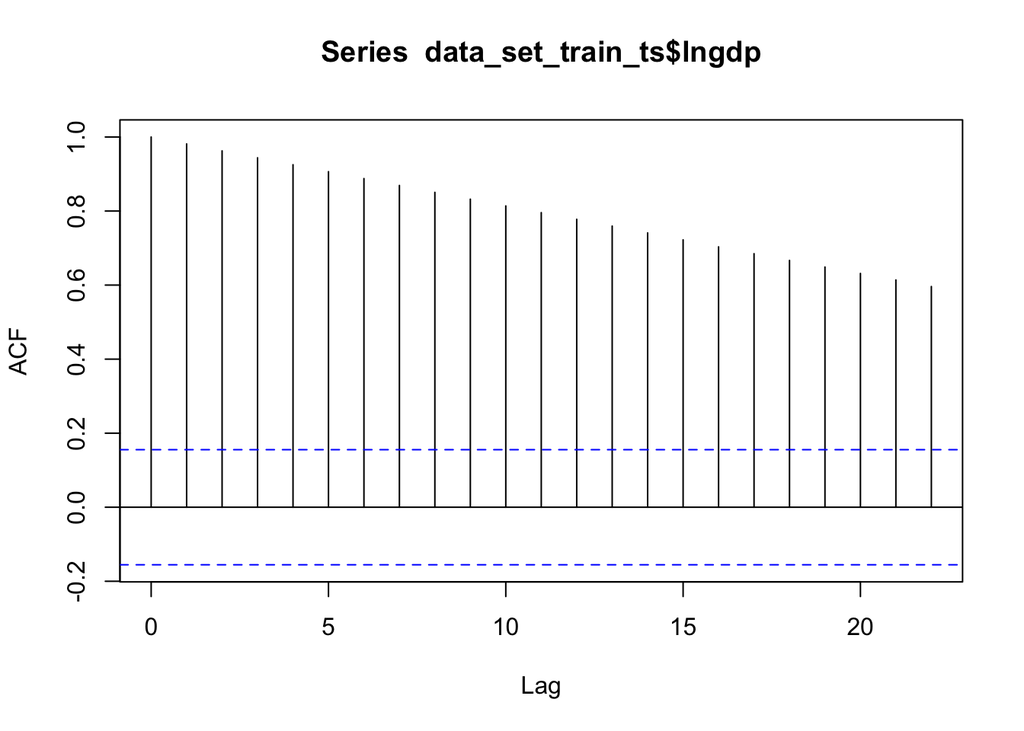

```r
# Test for stationarity (first difference) - df test
# Summary: Conclude that not all of them are I(1) and cannot proceed to testing for cointegration. Inflation is I(0) stationary
acf(data_set_train_ts$lngdp)
```

```r
summary(ur.df(data_set_train_ts$lngdp, type = c("trend"), selectlags = c("AIC"))) # no reject
```

```
##
## ###############################################
## # Augmented Dickey-Fuller Test Unit Root Test #
## ###############################################
##
## Test regression trend
##
##
## Call:
## lm(formula = z.diff ~ z.lag.1 + 1 + tt + z.diff.lag)
##
## Residuals:
##       Min        1Q    Median        3Q       Max
## -0.076235 -0.006813  0.000700  0.006810  0.040917
##
## Coefficients:
##               Estimate Std. Error t value Pr(>|t|)
## (Intercept)  0.0863948  0.0472112   1.830   0.0692 .
## z.lag.1     -0.0228123  0.0142679  -1.599   0.1119
## tt           0.0002970  0.0002012   1.476   0.1420
## z.diff.lag   0.3444072  0.0760183   4.531 1.18e-05 ***
## ---
## Signif. codes:  0 '***' 0.001 '**' 0.01 '*' 0.05 '.' 0.1 ' ' 1
##
## Residual standard error: 0.01382 on 153 degrees of freedom
## Multiple R-squared:  0.1347, Adjusted R-squared:  0.1178
## F-statistic: 7.942 on 3 and 153 DF,  p-value: 5.888e-05
##
##
## Value of test-statistic is: -1.5989 13.1832 1.6942
##
## Critical values for test statistics:
##       1pct  5pct 10pct
## tau3 -3.99 -3.43 -3.13
## phi2  6.22  4.75  4.07
## phi3  8.43  6.49  5.47
```

```r
summary(ur.df(data_set_train_ts$lngdp, type = c("drift"), selectlags = c("AIC"))) # no reject
```

```
##
## ###############################################
## # Augmented Dickey-Fuller Test Unit Root Test #
## ###############################################
##
## Test regression drift
##
##
## Call:
## lm(formula = z.diff ~ z.lag.1 + 1 + z.diff.lag)
##
## Residuals:
##       Min        1Q    Median        3Q       Max
## -0.080542 -0.006120  0.001478  0.006452  0.041013
##
## Coefficients:
##              Estimate Std. Error t value Pr(>|t|)
## (Intercept)  0.017706   0.007974   2.221   0.0278 *
## z.lag.1     -0.001910   0.001743  -1.096   0.2749
## z.diff.lag   0.331608   0.075811   4.374 2.24e-05 ***
## ---
## Signif. codes:  0 '***' 0.001 '**' 0.01 '*' 0.05 '.' 0.1 ' ' 1
##
## Residual standard error: 0.01387 on 154 degrees of freedom
## Multiple R-squared:  0.1224, Adjusted R-squared:  0.111
## F-statistic: 10.74 on 2 and 154 DF,  p-value: 4.297e-05
##
##
## Value of test-statistic is: -1.0958 18.5437
##
## Critical values for test statistics:
##       1pct  5pct 10pct
## tau2 -3.46 -2.88 -2.57
## phi1  6.52  4.63  3.81
```